# Perwalian Semester 2 Angkatan 2024 | S2 Statistika Terapan FMIPA Unpad

**S2 Statistika Terapan FMIPA Unpad** Pasca Sarjana Statistika · Universitas Padjadjaran

master.statistics.unpad.ac.id

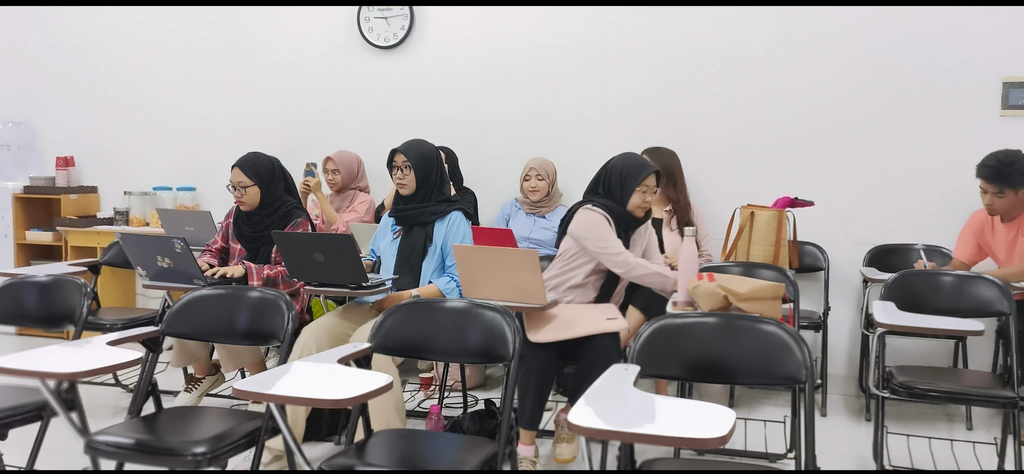

Berita Akademik · Perwalian Bersama

# Perwalian Semester 2 Angkatan 2024

Penentuan mata kuliah pilihan sesuai bidang minat, persiapan proposal tesis untuk Seminar Usulan Riset, strategi publikasi internasional, serta pembahasan calon pembimbing dan penguji tesis.

Senin, 10 Februari 2025 09.00–11.00 WIB Gedung Departemen Statistika FMIPA Unpad Semester Genap 2024/2025

Angkatan**Mahasiswa Angkatan 2024**

Semester**Semester 2 · Genap 2024/2025**

Beban Semester**17 SKS**

Agenda Utama**Mata kuliah pilihan dan proposal tesis**

## Mengarahkan pilihan akademik menuju topik tesis

Program Studi Magister Statistika Terapan FMIPA Universitas Padjadjaran menyelenggarakan kegiatan perwalian Semester 2 bagi mahasiswa Angkatan 2024 pada **Senin, 10 Februari 2025**. Kegiatan dilaksanakan secara luring di Gedung Departemen Statistika FMIPA Unpad pada pukul **09.00–11.00 WIB**.

Perwalian dipimpin oleh Ketua Program Studi S2 Statistika Terapan, **I Gede Nyoman Mindra Jaya**. Pertemuan berfokus pada penentuan mata kuliah pilihan sesuai bidang minat, pemahaman struktur Semester 2, penyiapan proposal tesis untuk Seminar Usulan Riset, serta perencanaan pembimbing dan penguji tesis.

**Prinsip utama yang disampaikan:** mata kuliah pilihan tidak sebaiknya dipilih hanya berdasarkan jadwal atau tingkat kesulitan, tetapi perlu mendukung kompetensi yang dibutuhkan dalam penelitian, arah karier, dan rencana publikasi mahasiswa.

## Struktur pembelajaran Semester 2

Pada Semester 2, mahasiswa menempuh total **17 SKS**. Struktur tersebut terdiri atas dua mata kuliah wajib, tiga mata kuliah pilihan, dan mata kuliah Seminar. Mata kuliah Seminar menjadi ruang awal untuk mematangkan gagasan penelitian sebelum mahasiswa memasuki tahapan Seminar Usulan Riset.

| No. | Mata Kuliah | SKS | Status |
| --- | --- | --- | --- |
| 1 | Statistika Nonparametrik dan Flexible Modeling | 3 (2+1) | Wajib |
| 2 | Data Mining and Artificial Intelligence | 3 (2+1) | Wajib |
| 3 | Mata Kuliah Pilihan 1 | 3 (2+1) | Pilihan |
| 4 | Mata Kuliah Pilihan 2 | 3 (2+1) | Pilihan |
| 5 | Mata Kuliah Pilihan 3 | 3 (2+1) | Pilihan |
| 6 | Seminar | 2 | Wajib |

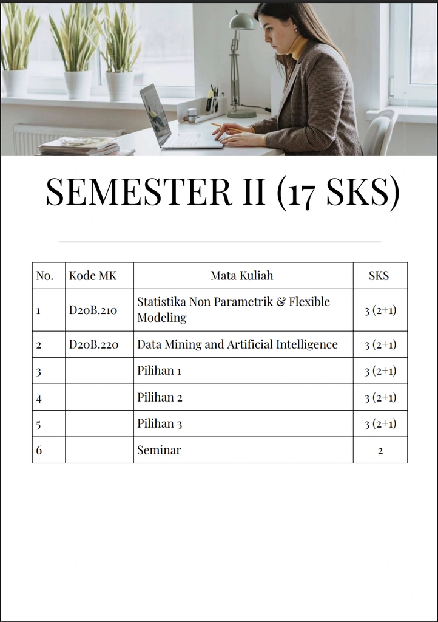

Struktur Semester 2: dua mata kuliah wajib, tiga pilihan, dan Seminar dengan total 17 SKS.

## Memilih mata kuliah sesuai bidang minat

Ketua Program Studi menjelaskan bahwa pemilihan mata kuliah perlu mempertimbangkan bidang minat, kompetensi yang ingin diperkuat, rencana topik tesis, kebutuhan metode, serta arah karier setelah lulus. Mahasiswa juga perlu melihat keterhubungan antarmata kuliah agar kombinasi pilihan yang diambil membentuk kompetensi yang utuh.

01

**Statistika Sosial**

Sampling Survey, Structural Equation Modelling, Analisis Data Kategori Tingkat Lanjut, dan Analisis Spasial Tingkat Lanjut.

02

**Bisnis dan Industri**

Structural Equation Modelling, Matematika Keuangan, Desain Eksperimen, Analisis Spasial Tingkat Lanjut, dan Quality Control.

03

**Biostatistika**

Epidemiologi, Survival Analysis, Desain Eksperimen, Analisis Kategori Tingkat Lanjut, dan Analisis Spasial Tingkat Lanjut.

04

**Aktuaria**

Matematika Aktuaria 1, Matematika Aktuaria 2, Matematika Keuangan, Survival Analysis, dan Teori Risiko.

05

**Sains Data**

Machine Learning, Image Processing, Text Analytic, dan Database.

Daftar mata kuliah pada setiap bidang minat digunakan sebagai panduan. Kombinasi akhir tetap perlu disesuaikan dengan mata kuliah yang ditawarkan, prasyarat, kapasitas kelas, rencana tesis, serta hasil konsultasi akademik.

## Penyiapan proposal tesis untuk SUR

Perwalian menekankan bahwa persiapan Seminar Usulan Riset perlu dimulai sejak Semester 2. Mahasiswa didorong untuk segera menentukan bidang masalah, menelaah literatur, mengenali kesenjangan penelitian, memastikan ketersediaan data, dan memilih metode statistika yang sesuai.

**Rumusan masalah yang fokus** Batasi ruang lingkup penelitian agar tujuan, data, dan metode dapat disusun secara konsisten.

**Telaah pustaka yang terarah** Gunakan artikel mutakhir untuk memetakan perkembangan metode dan menemukan kontribusi penelitian.

**Kesiapan data** Pastikan sumber, akses, variabel, kualitas, ukuran, dan etika penggunaan data telah dipertimbangkan.

**Keselarasan metode** Metode dipilih berdasarkan pertanyaan penelitian dan karakteristik data, bukan semata karena sedang populer.

**Target kerja mingguan** Pecah penulisan proposal menjadi target literatur, metodologi, data, dan draf presentasi yang terukur.

**Dokumentasi dan integritas** Kelola referensi, data, kode, hasil analisis, dan penggunaan teknologi secara transparan dan bertanggung jawab.

## Penentuan pembimbing dan penguji tesis

Dalam kegiatan ini juga dibahas mekanisme penentuan pembimbing dan penguji tesis. Kesesuaian bidang keahlian dengan topik penelitian menjadi pertimbangan utama. Selain itu, program studi memperhatikan kebutuhan metodologis, perspektif substantif, pemerataan beban akademik, serta ketersediaan dosen.

Mahasiswa diarahkan untuk menyiapkan ringkasan topik penelitian yang memuat latar belakang, tujuan, jenis data, metode yang direncanakan, dan kontribusi yang diharapkan. Ringkasan tersebut membantu program studi melakukan pemetaan pembimbing dan penguji secara lebih tepat.

## Strategi publikasi pada jurnal bereputasi internasional

Sesi berikutnya membahas strategi menyiapkan artikel untuk jurnal bereputasi internasional. Mahasiswa diingatkan agar publikasi dikembangkan dari penelitian yang memiliki pertanyaan jelas, data yang dapat dipertanggungjawabkan, metode yang tepat, hasil yang dapat direproduksi, dan kontribusi yang nyata.

Proses publikasi perlu diawali dengan pemilihan jurnal yang sesuai ruang lingkup, pemeriksaan reputasi dan kebijakan penerbit, penyusunan naskah mengikuti pedoman jurnal, serta kesiapan merespons komentar penelaah. Dalam perwalian juga disampaikan adanya peluang pembiayaan publikasi dari Universitas Padjadjaran sesuai skema, persyaratan, ketersediaan anggaran, dan ketentuan yang berlaku.

**Catatan penting:** dukungan biaya publikasi tidak menggantikan proses seleksi jurnal yang cermat. Mahasiswa tetap perlu menghindari jurnal predator, memeriksa indeksasi dan reputasi, serta memastikan kepatuhan pada etika kepengarangan dan integritas ilmiah.

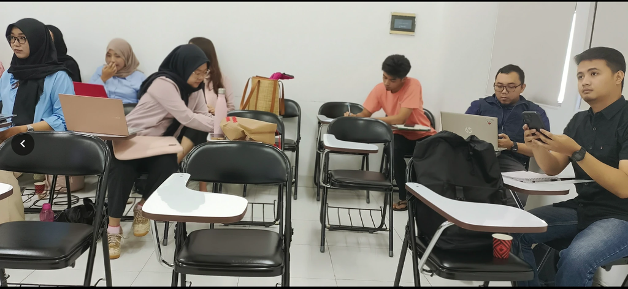

Suasana diskusi terkait mata kuliah pilihan, proposal tesis, dan persiapan publikasi.

## Target akademik setelah perwalian

Setelah kegiatan, mahasiswa diharapkan segera menyusun rencana studi Semester 2, menentukan kombinasi mata kuliah pilihan, menyiapkan ringkasan topik tesis, memulai telaah pustaka, dan mengidentifikasi kebutuhan pembimbing. Setiap mahasiswa juga didorong menyusun target waktu menuju Seminar Usulan Riset agar proses tesis pada semester berikutnya tidak mengalami keterlambatan.

Perwalian Semester 2 menjadi momentum untuk menyelaraskan pilihan mata kuliah, rencana tesis, komposisi pembimbing dan penguji, serta strategi publikasi. Dengan perencanaan yang matang, mahasiswa diharapkan mampu menyelesaikan setiap tahap akademik secara tepat waktu dan menghasilkan karya ilmiah yang bermutu.

### Pimpinan kegiatan

Ketua Program Studi **I Gede Nyoman Mindra Jaya** S2 Statistika Terapan FMIPA Unpad

### Mahasiswa Angkatan 2024

- SSyahla Anisah
- IInu Alifiyah Phalufi
- MMuhamad Ramdhani
- AAgy Aswad Ilham
- JJesicha Aulia Adam
- MMuhammad Restu Agam
- NNisa Akbarilah Putri
- AAnindya Nitisari
- LLeivina Saliaputri
- GGracia Joanne Crissan BR Hutabarat
- AAnggie Alnurin Prasetya
- DDisa Rahma Kirana
- NNisrina Aprilia Kamila
- LLuri Zahara
- MMuhammad Sahid

Total mahasiswa: 15 orang